# Assignment_4

3. WSS Method Transformation

```r
Pharma3_WSS <- cbind(Pharma[,c(12,13,14)],kmeans2$cluster)
colnames(Pharma3_WSS) <- c("Median_Recommendation", "Location", "Exchange", "Groups")
Pharma3_WSS$Groups <- as.numeric(Pharma3_WSS$Groups)
list(Pharma3_WSS)
```

```
## [[1]]
##    Median_Recommendation    Location Exchange Groups
## 1           Moderate Buy          US     NYSE      1
## 2           Moderate Buy      CANADA     NYSE      2
## 3             Strong Buy          UK     NYSE      2
## 4          Moderate Sell          UK     NYSE      1
## 5           Moderate Buy      FRANCE     NYSE      2
## 6                   Hold     GERMANY     NYSE      2
## 7          Moderate Sell          US     NYSE      1
## 8           Moderate Buy          US   NASDAQ      2
## 9          Moderate Sell     IRELAND     NYSE      2
## 10                  Hold          US     NYSE      1
## 11                  Hold          UK     NYSE      1
## 12                  Hold          US     AMEX      2
## 13          Moderate Buy          US     NYSE      1
## 14          Moderate Buy          US     NYSE      2
## 15                  Hold          US     NYSE      1
## 16                  Hold SWITZERLAND     NYSE      1
## 17          Moderate Buy          US     NYSE      1
## 18                  Hold          US     NYSE      2
## 19                  Hold          US     NYSE      1
## 20         Moderate Sell          US     NYSE      2
## 21                  Hold          US     NYSE      1
```

Median Recommendation v/s WSS CLusters

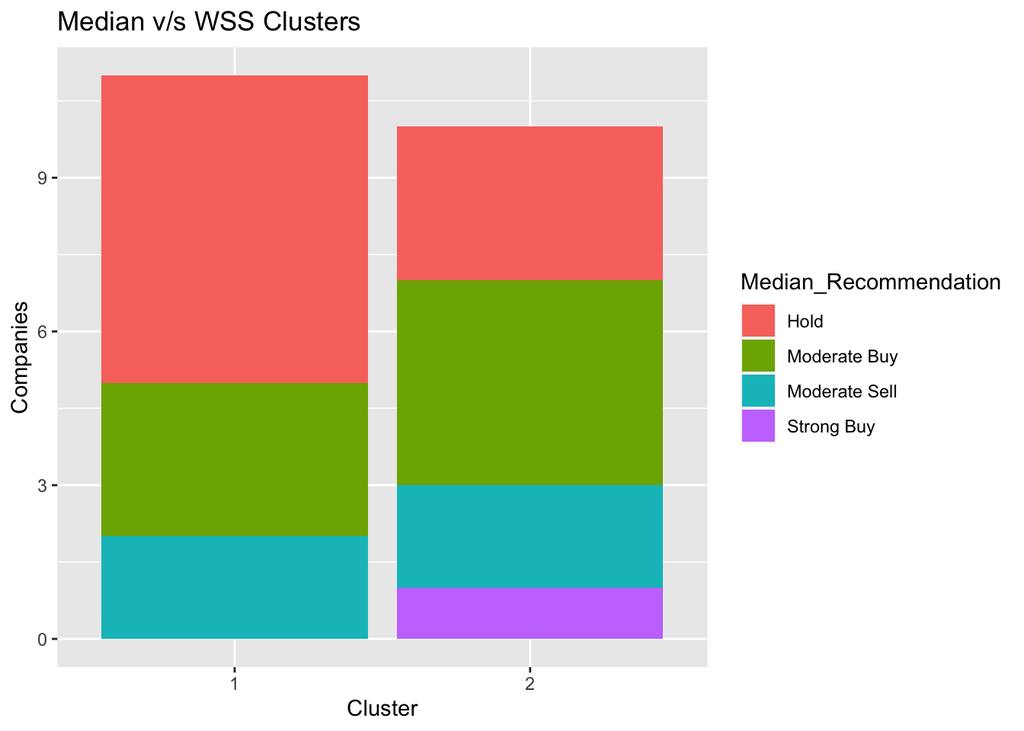

```r
ggplot(Pharma3_WSS, aes(fill = Median_Recommendation, x = as.factor(Groups))) +
geom_bar(position = 'stack') + labs(x="Cluster", y="Companies",
title = "Median v/s WSS Clusters")
```

In the above chart we can see that the cluster 1 has mixed recommendations and has hold recommendations it has moderate sell and buy, this is because of it’s high probability of profit due to the high value of Market Capital(73.84),ROA(15.0), ROE(31.0)and a Net profit margin(20.6) where as in cluster 2 we can visualize that the companies has a possibility to grow in the future aand can be profitable in business with the values of different profit measuring parameters.